# 병원데이터분석_6개 모델 테스트

Keeyoung Han

## 1. Getting the Data Into R

- 데이터셋 불러오기

```r
setwd("~/GitHub/Hospital")
dataset1 <- read.csv("dataset1_PHENOM.csv") #병명이 식별되지 않는 그룹
dataset2 <- read.csv("dataset2_PHENOM.csv") #병명이 식별되는 그룹.
```

## 2. Munging

- 각 데이터셋에 NA 값이 어떻게 분포되어 있는지 확인하기 (`Amelia` package의 함수를 이용)

```r
library(Amelia)
```

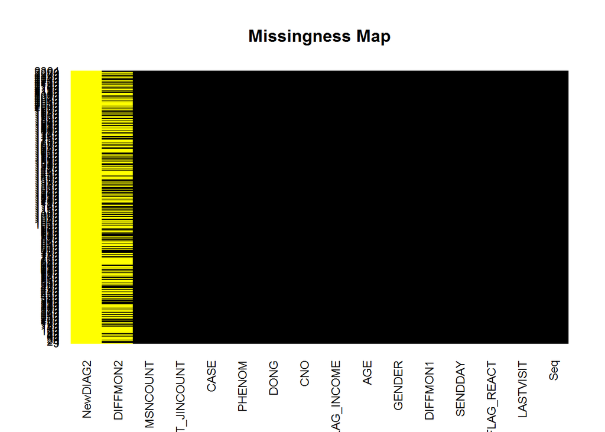

```r
missmap(dataset1, col=c("yellow", "black"), legend=FALSE)
```

`NewDIAG2(병명)`과 `DIFFMON2(문자받은 후 재검응답까지 개월수)`에 NA값이 존재

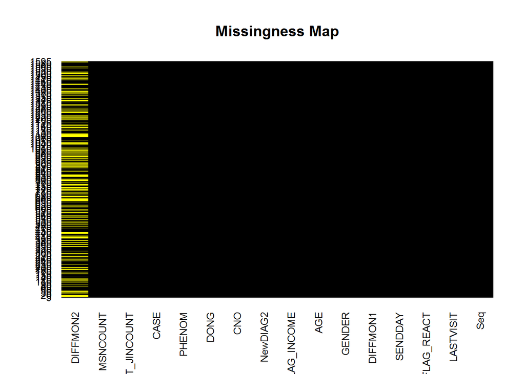

```r
missmap(dataset2, col=c("yellow", "black"), legend=FALSE)
```

`DIFFMON2(문자받은 후 재검응답까지 개월수)`에 NA값이 존재

잘못들어간 데이터 제거

```r
dataset1 <- subset(dataset1, !is.na(dataset1$Seq))
dataset2 <- subset(dataset2, !is.na(dataset2$Seq))
```

- 몇몇 변수 데이터형식 바꾸기

```r
dataset1$AGE <- as.factor(dataset1$AGE)
dataset2$AGE <- as.factor(dataset2$AGE)

dataset1$FLAG_INCOME <- as.factor(dataset1$FLAG_INCOME)
dataset2$FLAG_INCOME <- as.factor(dataset2$FLAG_INCOME)

dataset1$DIFFMON2 <- as.integer(dataset1$DIFFMON2)
dataset2$DIFFMON2 <- as.integer(dataset2$DIFFMON2)
```

- 예측하고자 하는 변수는 범주형으로 변환

```r
dataset1$FLAG_REACT[dataset1$FLAG_REACT ==0] <- "NO"
dataset1$FLAG_REACT[dataset1$FLAG_REACT ==1] <- "YES"
dataset2$FLAG_REACT[dataset2$FLAG_REACT ==0] <- "NO"
dataset2$FLAG_REACT[dataset2$FLAG_REACT ==1] <- "YES"
dataset1$FLAG_REACT <- as.factor(dataset1$FLAG_REACT)
dataset2$FLAG_REACT <- as.factor(dataset2$FLAG_REACT)
```

- 병명 업데이트 먼저 병명별 건수 확인하기

```r
table(dataset2$NewDIAG2)
```

```
##
## C5040 C5041 C5051   C73 D0509  D171   d24   D24  D240 D2409   D34  D360
##     4     1     1     8     1     3     2   575    72    40   421     2
##  E039 E0500  E059  E069  N601  N608   N61   N62  N644   R53
##    29   350     2    70     1     3     2     5     2     1
```

병명을 `C, D, E, N`으로 범주화하여 합치기

```r
dataset2 <- within( dataset2, {
    DIAG = character(0)
    DIAG[ grep("C", dataset2$NewDIAG2)] = "C"
    DIAG[ grep("d", dataset2$NewDIAG2)] = "D"
    DIAG[ grep("D", dataset2$NewDIAG2)] = "D"
    DIAG[ grep("E", dataset2$NewDIAG2)] = "E"
    DIAG[ grep("N", dataset2$NewDIAG2)] = "N"
    DIAG[ grep("R", dataset2$NewDIAG2)] = "N" #R은 N으로 합치기
    DIAG = factor(DIAG, level = c("C", "D", "E","N"))})
```

```r
table(dataset2$DIAG,useNA = "always")
```

```
##
##    C    D    E    N <NA>
##   14 1116  451   14    0
```

```r
dataset1 <- within( dataset1, {
    DIFFMON1_CD = character(0)
    DIFFMON1_CD[ DIFFMON1 >=0 & DIFFMON1 <4 ] = "SEND1"
    DIFFMON1_CD[ DIFFMON1 >=4 & DIFFMON1 <8 ] = "SEND2"
    DIFFMON1_CD[ DIFFMON1 >=8 ] = "SEND3"
    DIFFMON1_CD = factor(DIFFMON1_CD, level = c("SEND1", "SEND2", "SEND3"))})

dataset2 <- within( dataset2, {
    DIFFMON1_CD = character(0)
    DIFFMON1_CD[ DIFFMON1 >=0 & DIFFMON1 <4 ] = "SEND1"
    DIFFMON1_CD[ DIFFMON1 >=4 & DIFFMON1 <8 ] = "SEND2"
    DIFFMON1_CD[ DIFFMON1 >=8 ] = "SEND3"
    DIFFMON1_CD = factor(DIFFMON1_CD, level = c("SEND1", "SEND2", "SEND3"))})
```

문자발송 개월 구간별 반응 확인

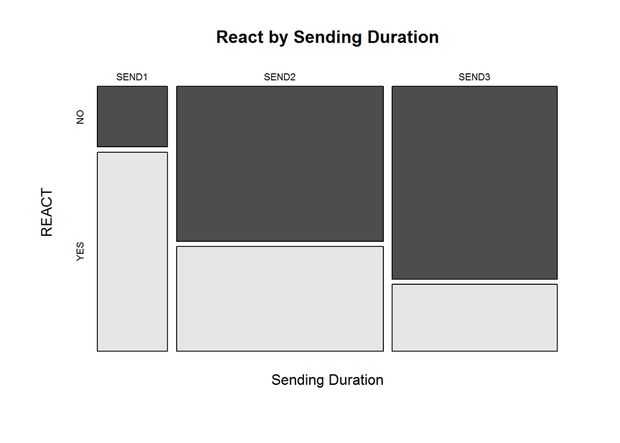

```r
mosaicplot(dataset1$DIFFMON1_CD ~ dataset1$FLAG_REACT,
           main="React by Sending Duration", shade=FALSE,
           color=TRUE, xlab="Sending Duration", ylab="REACT")
```

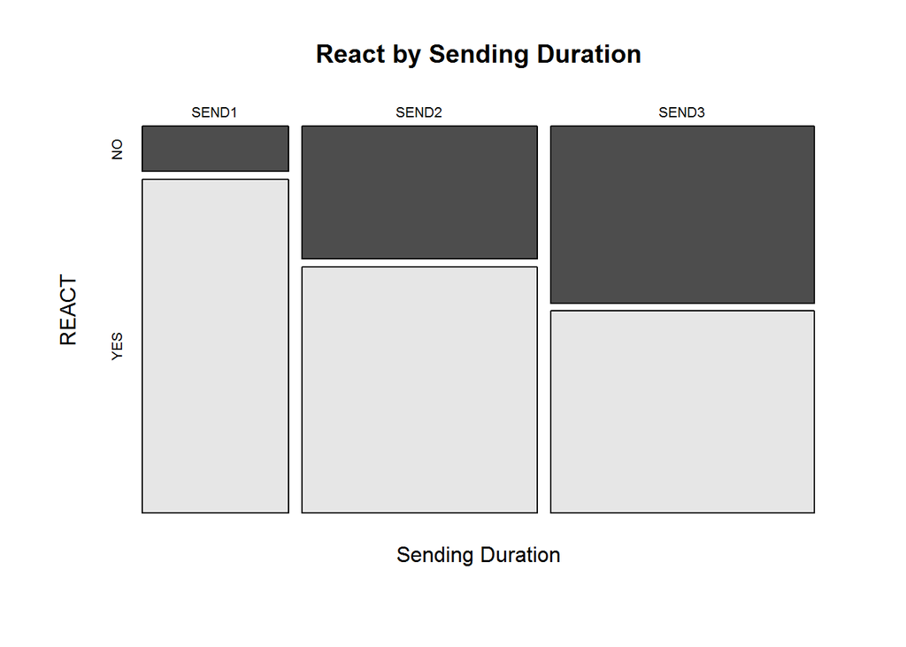

```r
mosaicplot(dataset2$DIFFMON1_CD ~ dataset2$FLAG_REACT,
           main="React by Sending Duration", shade=FALSE,
           color=TRUE, xlab="Sending Duration", ylab="REACT")
```

```r
dataset1 <- within( dataset1, {
    DIFFMON2_CD = character(0)
    DIFFMON2_CD[ DIFFMON2 >=0 & DIFFMON2 <3 ] = "REACT1"
    DIFFMON2_CD[ DIFFMON2 >=3 ] = "REACT2"
    DIFFMON2_CD[ is.na(DIFFMON2) ] = "NO_REACT"
    DIFFMON2_CD = factor(DIFFMON2_CD, level = c("REACT1", "REACT2", "NO_REACT"))})

dataset2 <- within( dataset2, {
    DIFFMON2_CD = character(0)
    DIFFMON2_CD[ DIFFMON2 >=0 & DIFFMON2 <3 ] = "REACT1"
    DIFFMON2_CD[ DIFFMON2 >=3 ] = "REACT2"
    DIFFMON2_CD[ is.na(DIFFMON2) ] = "NO_REACT"
    DIFFMON2_CD = factor(DIFFMON2_CD, level = c("REACT1", "REACT2", "NO_REACT"))})

table(dataset1$DIFFMON2_CD)
```

```
##
##   REACT1   REACT2 NO_REACT
##      537      400     1367
```

```r
table(dataset2$DIFFMON2_CD)
```

```
##
##   REACT1   REACT2 NO_REACT
##      582      462      551
```

```r
ds <- rbind(dataset1[, c("Seq", "FLAG_REACT", "DIFFMON1_CD", "CASE", "AGE", "FLAG_INCOME")], dataset2[,c("Seq", "FLAG_REACT", "DIFFMON1_CD", "CASE", "AGE", "FLAG_INCOME")]) #병명과 상관없는 전체 데이터
```

## 3. Fitting a Model

- train set, test set 만들기

```r
set.seed(10)
sub1 <- sample(nrow(dataset1), floor(nrow(dataset1) * 0.8))
ds1_train0 <- dataset1[sub1, ]
ds1_test0 <- dataset1[-sub1, ]

sub2 <- sample(nrow(dataset2), floor(nrow(dataset2) * 0.8))
ds2_train0 <- dataset2[sub2, ]
ds2_test0 <- dataset2[-sub2, ]

sub3 <- sample(nrow(ds), floor(nrow(ds) * 0.8))
ds_train0 <- ds[sub3, ]
ds_test0 <- ds[-sub3, ]
```

각 세트의 건수 확인

```r
nrow(ds1_train0)
```

```
## [1] 1843
```

```r
nrow(ds1_test0)
```

```
## [1] 461
```

```r
nrow(ds2_train0)
```

```
## [1] 1276
```

```r
nrow(ds2_test0)
```

```
## [1] 319
```

```r
nrow(ds_train0)
```

```
## [1] 3119
```

```r
nrow(ds_test0)
```

```
## [1] 780
```

- 필요한 라이브러리 로딩

```r
library(caret)
library(e1071)
library(pROC)
library(ada)
library(rpart)
library(rattle)
```

### 3.1 병명 없는 데이터

1)logistic regression

```r
cv.ctrl <- trainControl(method = "repeatedcv", repeats = 3,
                        summaryFunction = twoClassSummary,classProbs = TRUE)

tune.1.1 <- train(FLAG_REACT ~ DIFFMON1_CD + CASE + AGE,
                  data = ds1_train0, method = "glm",
                  metric = "ROC",  trControl = cv.ctrl)

# 적용
Prediction <- predict(tune.1.1, ds1_test0)

#정확도 계산
submit <- data.frame(Seq = ds1_test0$Seq, PREDICT_REACT = Prediction)
result <- merge(ds1_test0, submit, by = "Seq")
nrow(result[result$FLAG_REACT == result$PREDICT_REACT,]) / nrow(result)
```

```
## [1] 0.70282
```

2. AdaBoost

```r
## note the dot preceding each variable
ada.grid <- expand.grid(.iter = c(50, 100), .maxdepth = c(4, 8), .nu = c(0.1, 1))

##Specify method=”ada” and tuneGrid=ada.grid in train, and away we go...
ada.tune <- train(FLAG_REACT ~ DIFFMON1_CD + CASE + AGE, data = ds1_train0,
                  method = "ada", metric = "ROC", tuneGrid = ada.grid,
                  trControl = cv.ctrl)

# 적용
Prediction <- predict(ada.tune, ds1_test0)

# 정확도 계산
submit <- data.frame(Seq = ds1_test0$Seq, PREDICT_REACT = Prediction)
result <- merge(ds1_test0, submit, by = "Seq")
nrow(result[result$FLAG_REACT == result$PREDICT_REACT,]) / nrow(result)
```

```
## [1] 0.6984816
```

3. Random Forest 1

```r
rf.grid <- data.frame(.mtry = c(2, 3))

rf.tune <- train(FLAG_REACT ~ DIFFMON1_CD + CASE + AGE, data = ds1_train0,
                 method = "rf", metric = "ROC", tuneGrid = rf.grid,
                 trControl = cv.ctrl)

# 적용
Prediction <- predict(rf.tune, ds1_test0)

# 정확도 계산
submit <- data.frame(Seq = ds1_test0$Seq, PREDICT_REACT = Prediction)
result <- merge(ds1_test0, submit, by = "Seq")
nrow(result[result$FLAG_REACT == result$PREDICT_REACT,]) / nrow(result)
```

```
## [1] 0.6963124
```

4. support vector machine (SVM) model

```r
svm.tune <- train(FLAG_REACT ~ DIFFMON1_CD + CASE + AGE,  data = ds1_train0,
                  method = "svmRadial", tuneLength = 9, preProcess = c("center", "scale"),
                  metric = "ROC", trControl = cv.ctrl)

# 적용
Prediction <- predict(svm.tune, ds1_test0)

# 정확도 계산
submit <- data.frame(Seq = ds1_test0$Seq, PREDICT_REACT = Prediction)
result <- merge(ds1_test0, submit, by = "Seq")
nrow(result[result$FLAG_REACT == result$PREDICT_REACT,]) / nrow(result)
```

```
## [1] 0.6963124
```

5. 의사결정트리

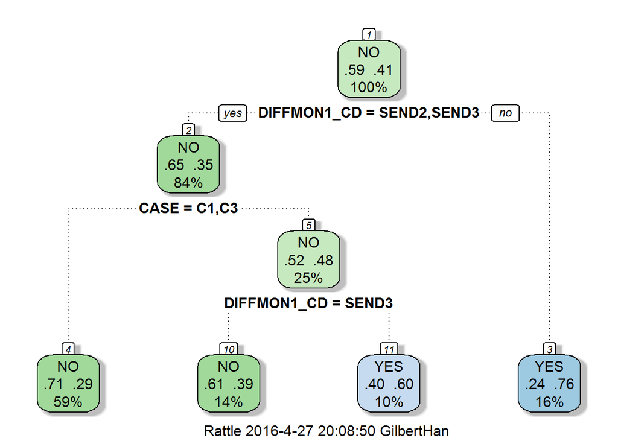

```r
fit11 <- rpart(FLAG_REACT ~ DIFFMON1_CD + CASE + AGE + FLAG_INCOME
               ,data=ds1_train0, method="class")

fancyRpartPlot(fit11)
```

```r
# 적용
Prediction <- predict(fit11, ds1_test0, type = "class")

# 정확도 계산
submit <- data.frame(Seq = ds1_test0$Seq, PREDICT_REACT = Prediction)
result <- merge(ds1_test0, submit, by = "Seq")
nrow(result[result$FLAG_REACT == result$PREDICT_REACT,])/nrow(result)
```

```
## [1] 0.7071584
```

6. Random Forest 2

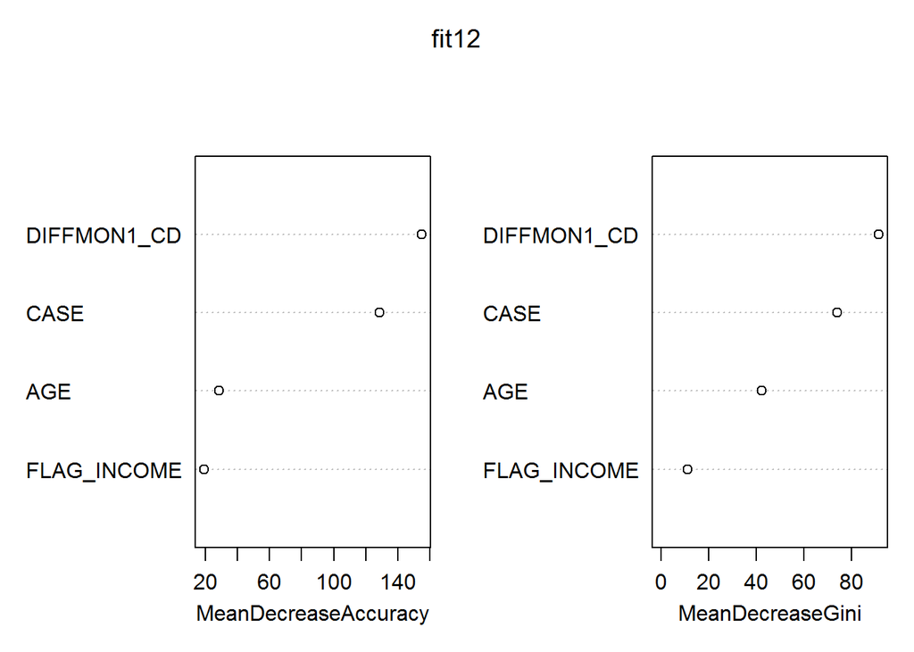

```r
fit12 <- randomForest(as.factor(FLAG_REACT) ~ DIFFMON1_CD + CASE + AGE + FLAG_INCOME
                      , data=ds1_train0, importance=TRUE, ntree=2000)

varImpPlot(fit12)
```

```r
# 적용
Prediction <- predict(fit12, ds1_test0)

# 정확도 계산
submit1 <- data.frame(Seq = ds1_test0$Seq, PREDICT_REACT = Prediction)
result <- merge(ds1_test0, submit1, by = "Seq")
nrow(result[result$FLAG_REACT == result$PREDICT_REACT,])/nrow(result)
```

```
## [1] 0.7114967
```

## 3.2 병명 있는 데이터터

1. logistic regression

```r
cv.ctrl <- trainControl(method = "repeatedcv", repeats = 3,
                        summaryFunction = twoClassSummary,classProbs = TRUE)

tune.2.1 <- train(FLAG_REACT ~ DIFFMON1_CD + CASE + DIAG
                  ,data = ds2_train0, method = "glm",
                  metric = "ROC",  trControl = cv.ctrl)

# 적용
Prediction <- predict(tune.2.1, ds2_test0)

# 정확도 계산
submit <- data.frame(Seq = ds2_test0$Seq, PREDICT_REACT = Prediction)
result <- merge(ds1_test0, submit, by = "Seq")
nrow(result[result$FLAG_REACT == result$PREDICT_REACT,]) / nrow(result)
```

```
## [1] 0.4558824
```

2. AdaBoost

```r
## note the dot preceding each variable
ada.grid <- expand.grid(.iter = c(50, 100), .maxdepth = c(4, 8), .nu = c(0.1, 1))

##Specify method=”ada” and tuneGrid=ada.grid in train, and away we go...
ada.tune <- train(FLAG_REACT ~ DIFFMON1_CD + CASE + DIAG, data = ds2_train0,
                  method = "ada", metric = "ROC", tuneGrid = ada.grid,
                  trControl = cv.ctrl)

# 적용
Prediction <- predict(ada.tune, ds2_test0)

# 정확도 계산
submit <- data.frame(Seq = ds2_test0$Seq, PREDICT_REACT = Prediction)
result <- merge(ds2_test0, submit, by = "Seq")
nrow(result[result$FLAG_REACT == result$PREDICT_REACT,]) / nrow(result)
```

```
## [1] 0.7021944
```

3. Random Forest 1

```r
rf.grid <- data.frame(.mtry = c(2, 3))

rf.tune.2 <- train(FLAG_REACT ~ DIFFMON1_CD + CASE + DIAG + AGE, data = ds2_train0,
                   method = "rf", metric = "ROC", tuneGrid = rf.grid,
                   trControl = cv.ctrl)

# 적용
Prediction <- predict(rf.tune, ds2_test0)

# 정확도 계산
submit <- data.frame(Seq = ds2_test0$Seq, PREDICT_REACT = Prediction)
result <- merge(ds2_test0, submit, by = "Seq")
nrow(result[result$FLAG_REACT == result$PREDICT_REACT,]) / nrow(result)
```

```
## [1] 0.5956113
```

4. support vector machine (SVM) model

```r
svm.tune <- train(FLAG_REACT ~ DIFFMON1_CD + CASE +  DIAG +AGE,  data = ds2_train0,
                  method = "svmRadial", tuneLength = 9, preProcess = c("center", "scale"),
                  metric = "ROC", trControl = cv.ctrl)


# 적용
Prediction <- predict(svm.tune, ds2_test0)

# 정확도 계산
submit <- data.frame(Seq = ds2_test0$Seq, PREDICT_REACT = Prediction)
result <- merge(ds2_test0, submit, by = "Seq")
nrow(result[result$FLAG_REACT == result$PREDICT_REACT,]) / nrow(result)
```

```
## [1] 0.6896552
```

5. 의사결정트리

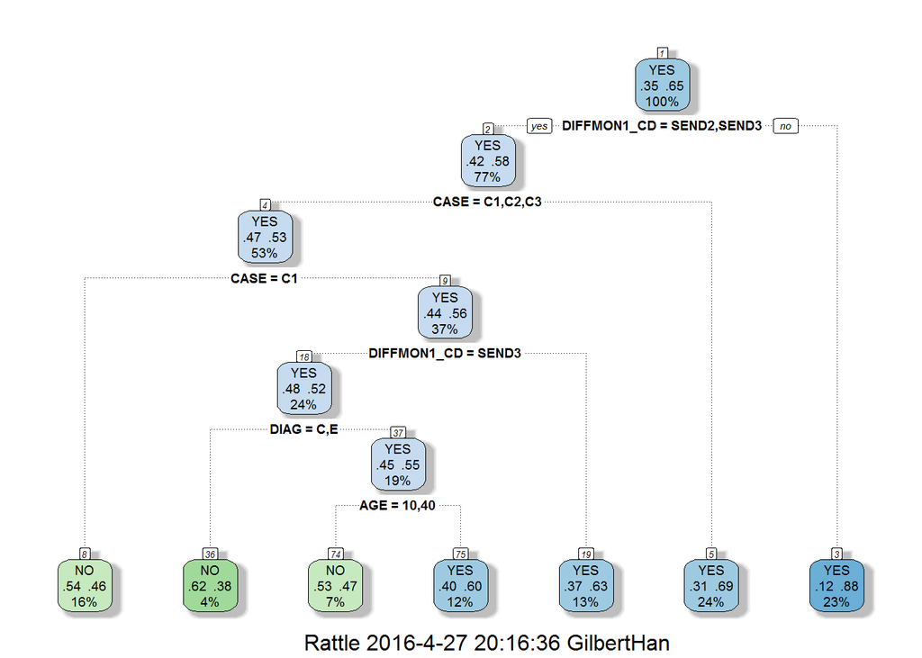

```r
fit12 <- rpart(FLAG_REACT ~ DIFFMON1_CD + CASE + DIAG +AGE
               ,data=ds2_train0, method="class")

fancyRpartPlot(fit12)
```

```r
# 적용 및 정확도 계산
Prediction <- predict(fit11, ds2_test0, type = "class")
submit <- data.frame(Seq = ds2_test0$Seq, PREDICT_REACT = Prediction)
result <- merge(ds2_test0, submit, by = "Seq")
nrow(result[result$FLAG_REACT == result$PREDICT_REACT,])/nrow(result)
```

```
## [1] 0.6144201
```

6. Random Forest 2

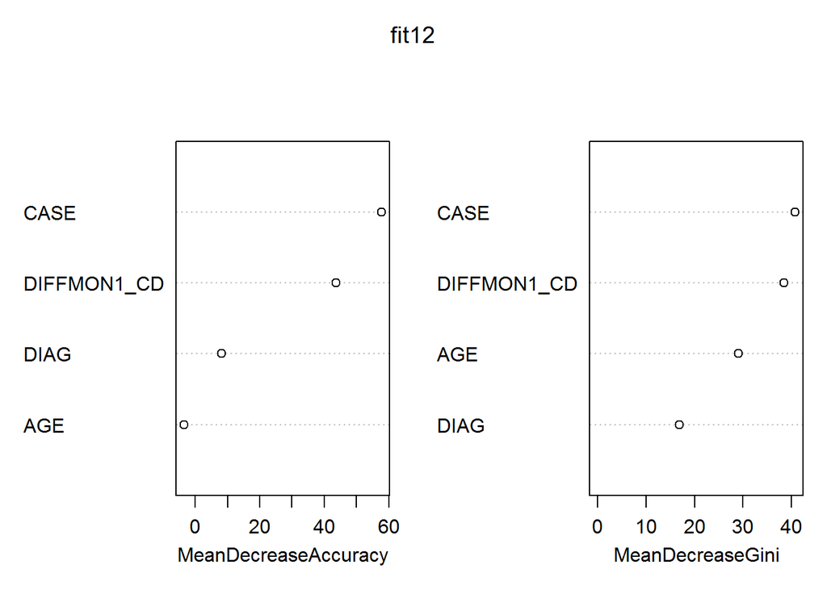

```r
fit12 <- randomForest(as.factor(FLAG_REACT) ~ DIFFMON1_CD + CASE + DIAG +AGE
                      , data=ds2_train0, importance=TRUE, ntree=2000)

varImpPlot(fit12)
```

```r
# 적용
Prediction <- predict(fit12, ds2_test0)

#  및 정확도 계산
submit1 <- data.frame(Seq = ds2_test0$Seq, PREDICT_REACT = Prediction)
result <- merge(ds2_test0, submit1, by = "Seq")
nrow(result[result$FLAG_REACT == result$PREDICT_REACT,])/nrow(result)
```

```
## [1] 0.6833856
```

## 3.4 통합데이터

1. logistic regression

```r
cv.ctrl <- trainControl(method = "repeatedcv", repeats = 3,
                        summaryFunction = twoClassSummary,classProbs = TRUE)

tune.1 <- train(FLAG_REACT ~ DIFFMON1_CD + CASE + AGE
                  ,data = ds_train0, method = "glm",
                  metric = "ROC",  trControl = cv.ctrl)

# 적용
Prediction <- predict(tune.1, ds_test0)

# 정확도 계산
submit <- data.frame(Seq = ds_test0$Seq, PREDICT_REACT = Prediction)
result <- merge(ds_test0, submit, by = "Seq")
nrow(result[result$FLAG_REACT == result$PREDICT_REACT,]) / nrow(result)
```

```
## [1] 0.6004415
```

2. AdaBoost

```r
## note the dot preceding each variable
ada.grid <- expand.grid(.iter = c(50, 100), .maxdepth = c(4, 8), .nu = c(0.1, 1))

##Specify method=”ada” and tuneGrid=ada.grid in train, and away we go...
ada.tune <- train(FLAG_REACT ~ DIFFMON1_CD + CASE + AGE, data = ds_train0,
                  method = "ada", metric = "ROC", tuneGrid = ada.grid,
                  trControl = cv.ctrl)

# 적용
Prediction <- predict(ada.tune, ds_test0)

# 정확도 계산
submit <- data.frame(Seq = ds_test0$Seq, PREDICT_REACT = Prediction)
result <- merge(ds_test0, submit, by = "Seq")
nrow(result[result$FLAG_REACT == result$PREDICT_REACT,]) / nrow(result)
```

```
## [1] 0.6048565
```

3. Random Forest 1

```r
rf.grid <- data.frame(.mtry = c(2, 3))

rf.tune <- train(FLAG_REACT ~ DIFFMON1_CD + CASE + AGE, data = ds_train0,
                   method = "rf", metric = "ROC", tuneGrid = rf.grid,
                   trControl = cv.ctrl)

# 적용
Prediction <- predict(rf.tune, ds_test0)

# 정확도 계산
submit <- data.frame(Seq = ds_test0$Seq, PREDICT_REACT = Prediction)
result <- merge(ds_test0, submit, by = "Seq")
nrow(result[result$FLAG_REACT == result$PREDICT_REACT,]) / nrow(result)
```

[output not shown]

4. support vector machine (SVM) model

```r
svm.tune <- train(FLAG_REACT ~ DIFFMON1_CD + CASE +  AGE,  data = ds_train0,
                  method = "svmRadial", tuneLength = 9, preProcess = c("center", "scale"),
                  metric = "ROC", trControl = cv.ctrl)


# 적용
Prediction <- predict(svm.tune, ds_test0)

# 정확도 계산
submit <- data.frame(Seq = ds_test0$Seq, PREDICT_REACT = Prediction)
result <- merge(ds_test0, submit, by = "Seq")
nrow(result[result$FLAG_REACT == result$PREDICT_REACT,]) / nrow(result)
```

```
## [1] 0.6004415
```

5. 의사결정트리

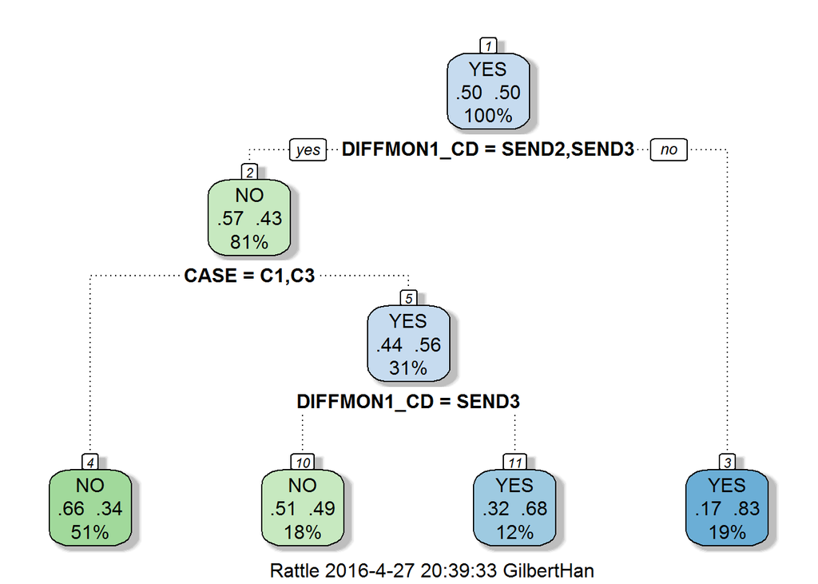

```r
fit12 <- rpart(FLAG_REACT ~ DIFFMON1_CD + CASE + AGE
               ,data=ds_train0, method="class")

fancyRpartPlot(fit12)
```

```r
# 적용 및 정확도 계산
Prediction <- predict(fit11, ds_test0, type = "class")
submit <- data.frame(Seq = ds_test0$Seq, PREDICT_REACT = Prediction)
result <- merge(ds_test0, submit, by = "Seq")
nrow(result[result$FLAG_REACT == result$PREDICT_REACT,])/nrow(result)
```

```
## [1] 0.607064
```

6. Random Forest 2

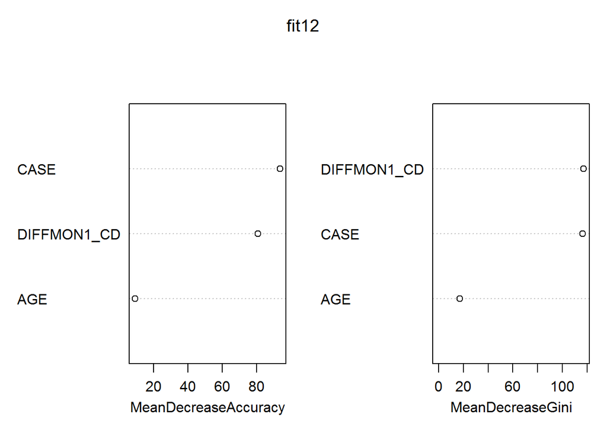

```r
fit12 <- randomForest(as.factor(FLAG_REACT) ~ DIFFMON1_CD + CASE + AGE
                      , data=ds_train0, importance=TRUE, ntree=2000)

varImpPlot(fit12)
```

```r
# 적용
Prediction <- predict(fit12, ds_test0)

#  및 정확도 계산
submit1 <- data.frame(Seq = ds_test0$Seq, PREDICT_REACT = Prediction)
result <- merge(ds2_test0, submit1, by = "Seq")
nrow(result[result$FLAG_REACT == result$PREDICT_REACT,])/nrow(result)
```

```
## [1] 0.5165563
```